# MP2_Sonam

Sonam Rathod

2024-10-24

# Insurance DataSet Forecast

#### 1. Create Timeseries

```r
library(forecast)
```

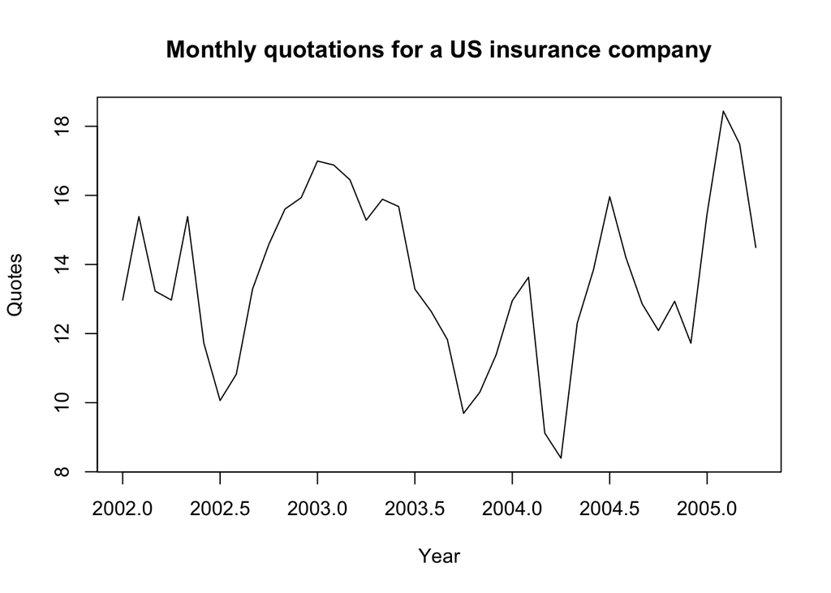

```r
insurance <- read.csv("~/Documents/Rutgers/Course/Business Forecasting/insurance.csv")
ins_ts <- ts(insurance$Quotes, start = c(2002,1) , end = c(2005,4), frequency = 12)

plot(ins_ts, main='Monthly quotations for a US insurance company', xlab ='Year', ylab='Quotes')
```

#### 2. Verify how much history to include in your analysis.

```r
summary(ins_ts)
```

```
##    Min. 1st Qu.  Median    Mean 3rd Qu.    Max.
##   8.395  12.023  13.287  13.604  15.505  18.439
```

Since the mean is close to the median, the distribution of quotes is fairly balanced with no extreme outliers that heavily affect the average. Since the data is almost evenly distributed, it is appropriate to include the entire dataset in the analysis to better capture the underlying seasonality and trend patterns.

#### 3. Hypothesize if the dataset has trend, seasonality, or both.

According to timeseries plot, data is fluctuating over the month. It is very hard to say if the dataset has trend or seasonality.

#### 4. Verify using Acf

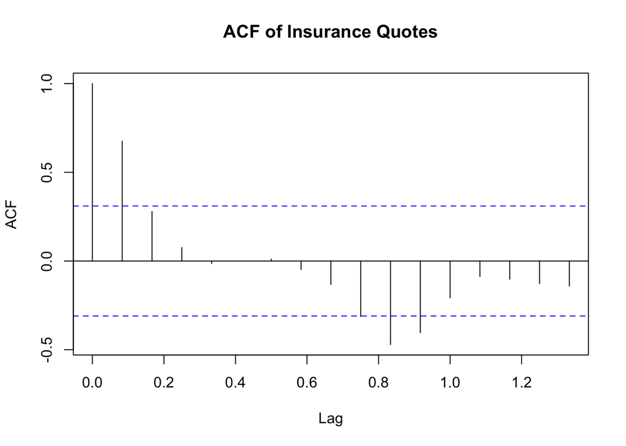

```r
acf(ins_ts, main = "ACF of Insurance Quotes")
```

There is no repeating pattern in acf, meaning data does not exhibit clear seasonality. Also, there is positive autocorrelation at lag 1 and lag 2 and then it is decreasing. There is short term trend.

#### 5. Verify using decomposition

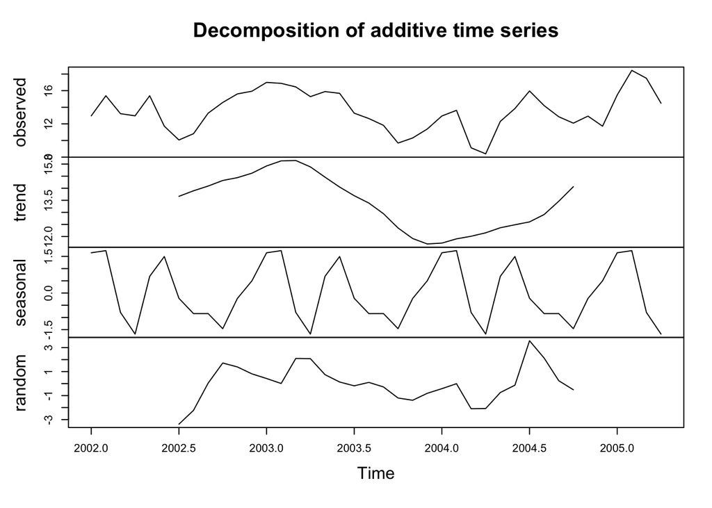

```r
insurance_decomp <- decompose(ins_ts)
plot(insurance_decomp)
```

- **Trend**: Decomposition shows upward trend from mid 2002 to 2003 and after that is decreasing till 2004 and afterwards gaining momentum.
- **Seasonality**: There is seasonality, though it not strong as patterns are not repeating consistently.

Based on the decomposition, we can say that there is trend and seasonality.

#### 6. Chose an accuracy measure

Going with common accuracy measures Root Mean Squared Error (RMSE) as it penalizes larger errors more heavily than smaller ones because it squares the forecast errors before averaging them.

#### 7. Create a forecast model for the next 12 months. Include Naive, Average, Exponential Smoothing, HoltWinters, and Decomposition (both types).

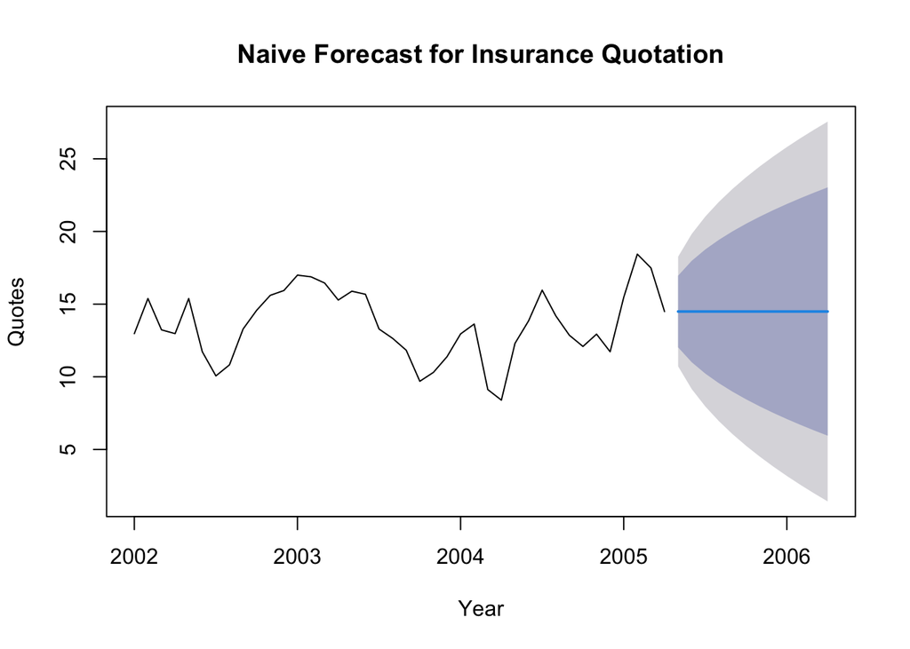

```r
naive_model <- naive(ins_ts, h = 12)
plot(naive_model, main = "Naive Forecast for Insurance Quotation",  xlab ='Year', ylab='Quotes')
```

**Naive Model**: The simplest model, forecasting that future values will be the same as the last observed value. The forecasted line is constant and flat for the next 12 months. This model is simple and works well when no clear trend or seasonality, though it may not be very accurate for time series data with trends or seasonal patterns.

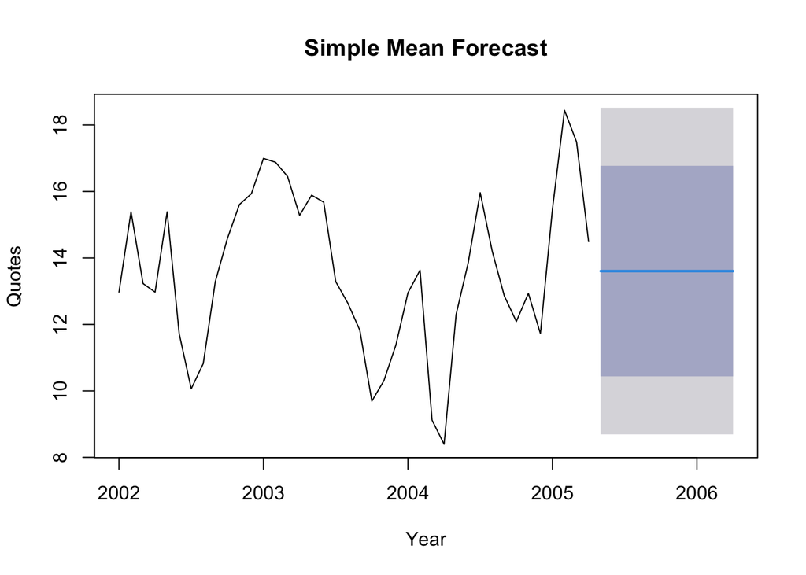

```r
simple_forecast <- meanf(ins_ts, h=12)
plot(simple_forecast, main="Simple Mean Forecast",  xlab ='Year', ylab='Quotes')
```

**Simple Average Model**: This forecasts using the mean of all historical observations. It shows the flat line for future even if there is a trend or seasonality.

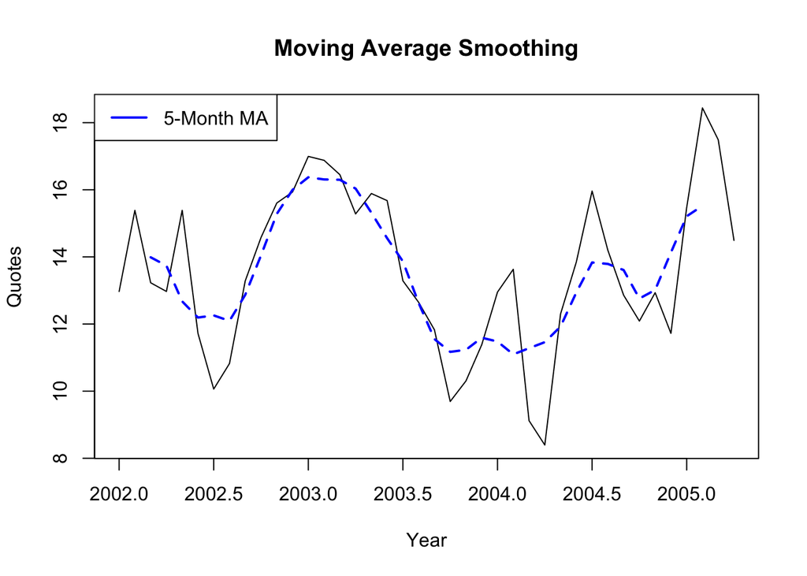

```r
# Apply Moving Average with a window of 5
MA5_forecast <- ma(ins_ts, order = 5)

# Plot the original time series
plot(ins_ts, main = "Moving Average Smoothing",  xlab ='Year', ylab='Quotes', col = "black")

lines(MA5_forecast, col = "blue", lwd = 2, lty = 2)

# Add a legend to differentiate the series
legend("topleft", legend = c( "5-Month MA"),
    col = c( "blue"), lty = 1:2, lwd = 2)
```

**Moving Average**: The moving average helps smooth out fluctuations in the time series to reveal the overall pattern. While there are some ups and downs, they are irregular and don’t happen at predictable intervals. No clear trend, just periods of increase and decrease without a steady rise or fall across the years.

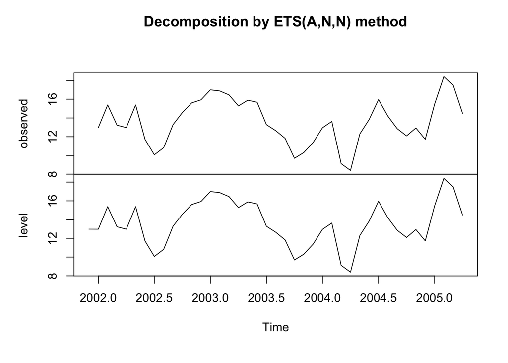

```r
ets_forecasting <- ets(ins_ts)
plot(ets_forecasting)
```

```r
summary(ets_forecasting)
```

```
## ETS(A,N,N)
##
## Call:
## ets(y = ins_ts)
##
##   Smoothing parameters:
##     alpha = 0.9999
##
##   Initial states:
##     l = 12.9764
##
##   sigma:  1.9495
##
##      AIC     AICc      BIC
## 204.9094 205.5760 209.9760
##
## Training set error measures:
##                      ME    RMSE      MAE        MPE     MAPE      MASE
## Training set 0.03789375 1.90014 1.534297 -0.8520511 11.85775 0.4470514
##                   ACF1
## Training set 0.1030891
```

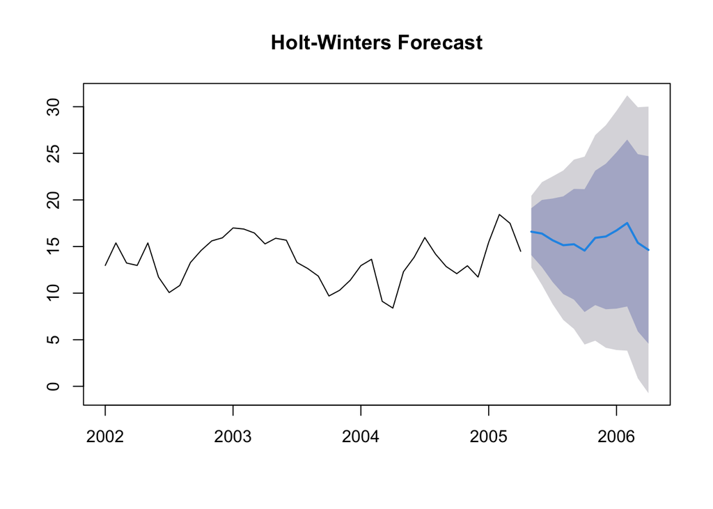

```r
hw_forecast <- hw(ins_ts, h=12)
plot(hw_forecast, main="Holt-Winters Forecast")
```

```r
summary(hw_forecast, xlab ='Year', ylab='Quotes')
```

```
##
## Forecast method: Holt-Winters' additive method
##
## Model Information:
## Holt-Winters' additive method
##
## Call:
## hw(y = ins_ts, h = 12)
##
##   Smoothing parameters:
##     alpha = 0.9999
##     beta  = 0.0272
##     gamma = 1e-04
##
##   Initial states:
##     l = 13.4243
##     b = -0.1468
##     s = 0.236 0.0967 -1.2543 -0.5618 -0.6536 -0.1118
##            0.6199 0.8343 -1.2545 -0.4778 1.6549 0.8719
##
##   sigma:  1.9646
##
##      AIC     AICc      BIC
## 215.1433 242.9614 243.8542
##
## Error measures:
##                     ME     RMSE      MAE       MPE     MAPE      MASE      ACF1
## Training set 0.1461692 1.521735 1.224394 0.3518439 9.201383 0.3567545 0.1785965
##
## Forecasts:
##          Point Forecast     Lo 80    Hi 80      Lo 95    Hi 95
## May 2005       16.59288 14.075207 19.11055 12.7424310 20.44333
## Jun 2005       16.39019 12.781163 19.99922 10.8706596 21.90972
## Jul 2005       15.67078 11.190837 20.15072  8.8193000 22.52225
## Aug 2005       15.14101  9.898643 20.38337  7.1235028 23.15851
## Sep 2005       15.24483  9.305801 21.18385  6.1618715 24.32778
## Oct 2005       14.56444  7.972919 21.15595  4.4835805 24.64529
## Nov 2005       15.92726  8.714776 23.13975  4.8967153 26.95781
## Dec 2005       16.07874  8.268680 23.88880  4.1342834 28.02320
## Jan 2006       16.72694  8.337148 25.11674  3.8958598 29.55802
## Feb 2006       17.52197  8.566298 26.47765  3.8254509 31.21849
## Mar 2006       15.40104  5.890370 24.91170  0.8557269 29.94635
## Apr 2006       14.63612  4.579076 24.69316 -0.7447997 30.01703
```

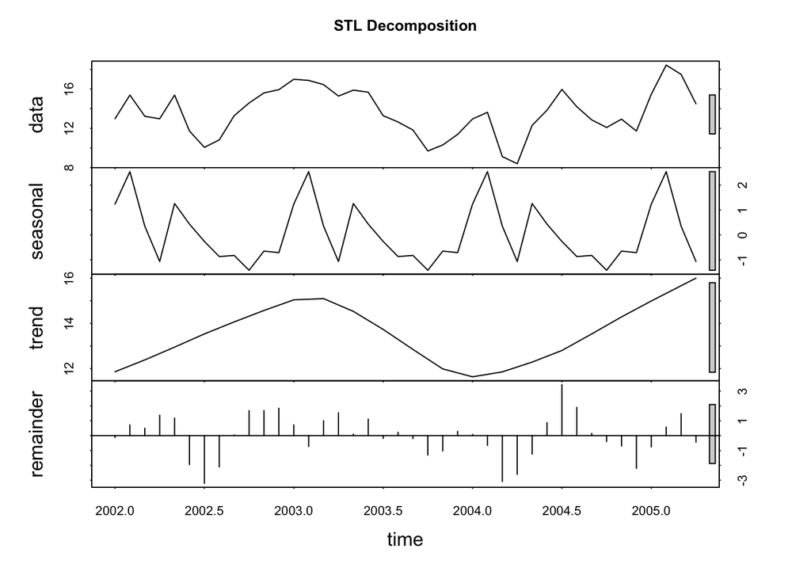

```r
ins_stl <- stl(ins_ts, s.window = "periodic")
plot(ins_stl, main = "STL Decomposition")
```

```r
summary(ins_stl)
```

```
##  Call:
##  stl(x = ins_ts, s.window = "periodic")
##
##  Time.series components:
##     seasonal              trend            remainder
##  Min.   :-1.4220646   Min.   :11.63675   Min.   :-3.208784
##  1st Qu.:-0.8368990   1st Qu.:12.40920   1st Qu.:-0.738765
##  Median :-0.2637104   Median :13.53407   Median : 0.088746
##  Mean   : 0.0764041   Mean   :13.53933   Mean   :-0.011389
##  3rd Qu.: 1.2352196   3rd Qu.:14.58885   3rd Qu.: 1.030572
##  Max.   : 2.5416172   Max.   :16.00177   Max.   : 3.425011
##  IQR:
##      STL.seasonal STL.trend STL.remainder data
##      2.072        2.180     1.769         3.482
##    %  59.5         62.6      50.8         100.0
##
##  Weights: all == 1
##
##  Other components: List of 5
##  $ win  : Named num [1:3] 401 19 13
##  $ deg  : Named int [1:3] 0 1 1
##  $ jump : Named num [1:3] 41 2 2
##  $ inner: int 2
##  $ outer: int 0
```

- The seasonal component accounts for around 59.5% of the variation.
- The trend component contributes to 62.6% of the data’s variability.
- The remainder (residuals) accounts for 50.8% of the variance.

There is some seasonality and a notable trend, the high contribution of residuals suggests that random variations play a significant role in this time series.

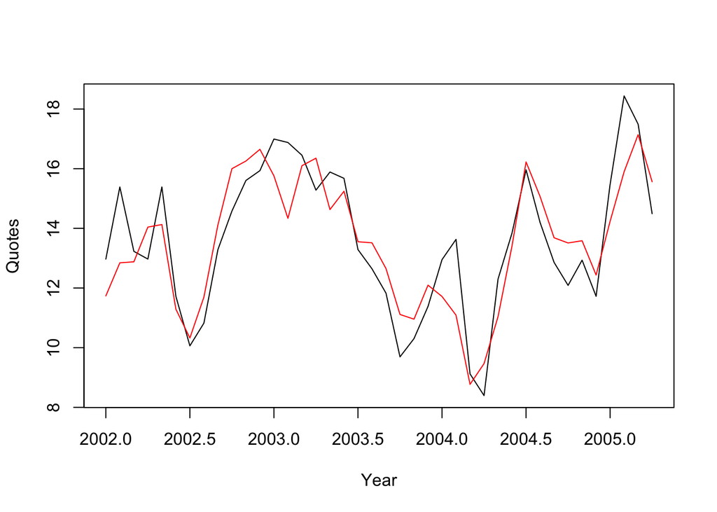

```r
plot(ins_ts,  xlab ='Year', ylab='Quotes')

lines(seasadj(ins_stl), col="Red")
```

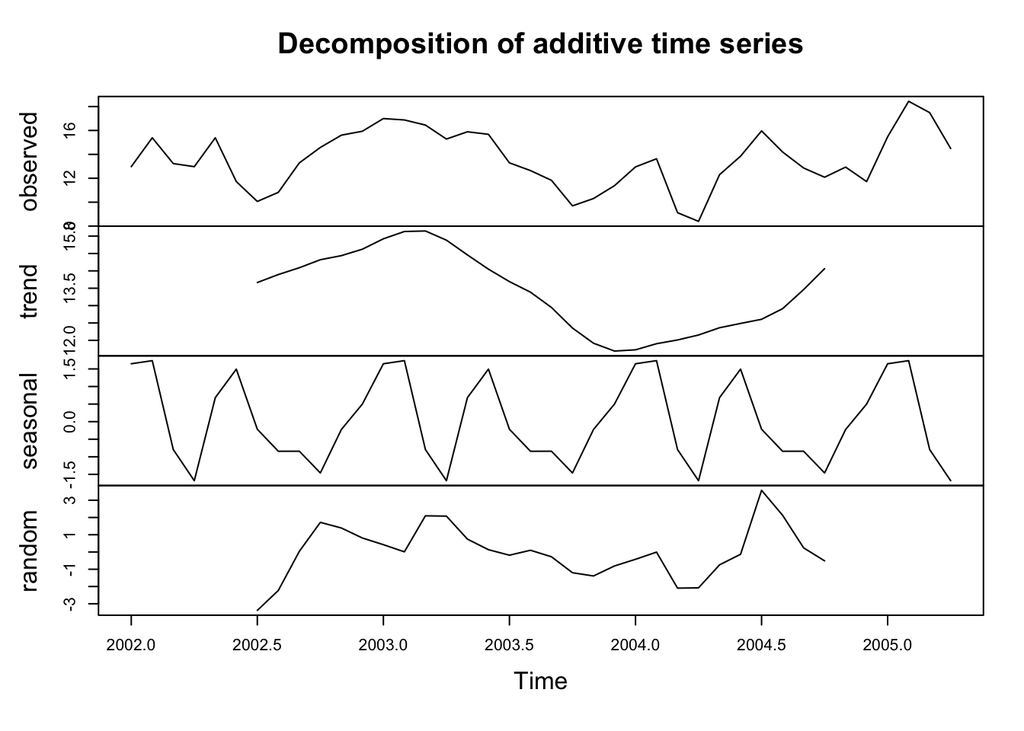

```r
decomposed_additive <- decompose(ins_ts, type = "additive")
plot(decomposed_additive)
```

This decomposition tells us that your data has some slight repeating cycles, a gentle trend, but also a lot of randomness.

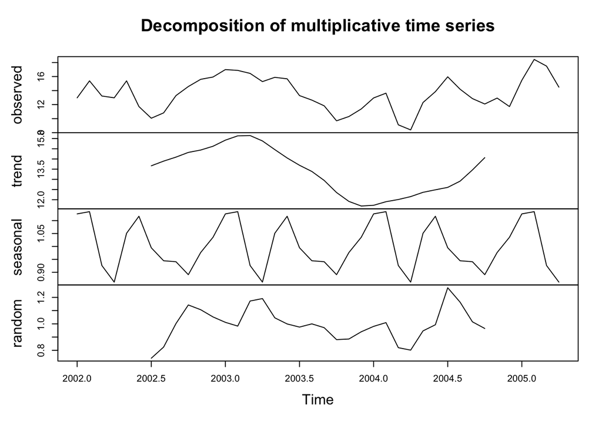

```r
decomposed_multiplicative <- decompose(ins_ts, type = "multiplicative")
plot(decomposed_multiplicative)
```

This decomposition tells us that your data has some slight repeating cycles, a gentle trend, but also a lot of randomness.

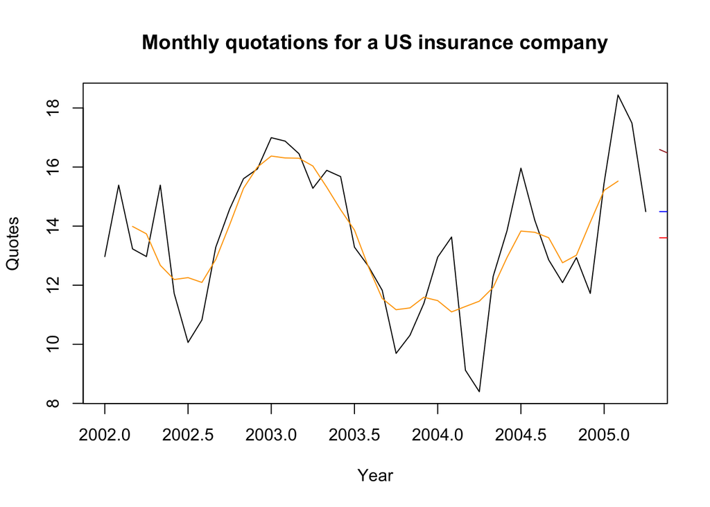

```r
plot(ins_ts,main='Monthly quotations for a US insurance company', xlab ='Year', ylab='Quotes')

# Add the forecasts to the plot
lines(naive_model$mean, col = "blue")
lines(simple_forecast$mean, col = "red")
lines(ets_forecasting$mean, col = "green")
lines(hw_forecast$mean, col = "brown")
lines(MA5_forecast, col = "orange")
```

#### 8. Show model rank with accuracy measures

```r
accuracy_naive <- accuracy(naive_model)
accuracy_avg <- accuracy(simple_forecast)
accuracy_ets <- accuracy(ets_forecasting)
accuracy_hw <- accuracy(hw_forecast)

accuracy_table <- data.frame(
  Model = c("Naive", "Average", "ETS", "Holt-Winters"),
  RMSE = c(accuracy_naive["Training set", "RMSE"], accuracy_avg["Training set", "RMSE"], accuracy_ets["Training set", "RMSE"], accuracy_hw["Training set", "RMSE"]))

accuracy_table$Model_Rank <- rank(accuracy_table$RMSE)
print(accuracy_table)
```

```
##          Model     RMSE Model_Rank
## 1        Naive 1.924326          3
## 2      Average 2.369165          4
## 3          ETS 1.900140          2
## 4 Holt-Winters 1.521735          1
```

#### 9. Choose which models and how are you going to use them for Forecasting

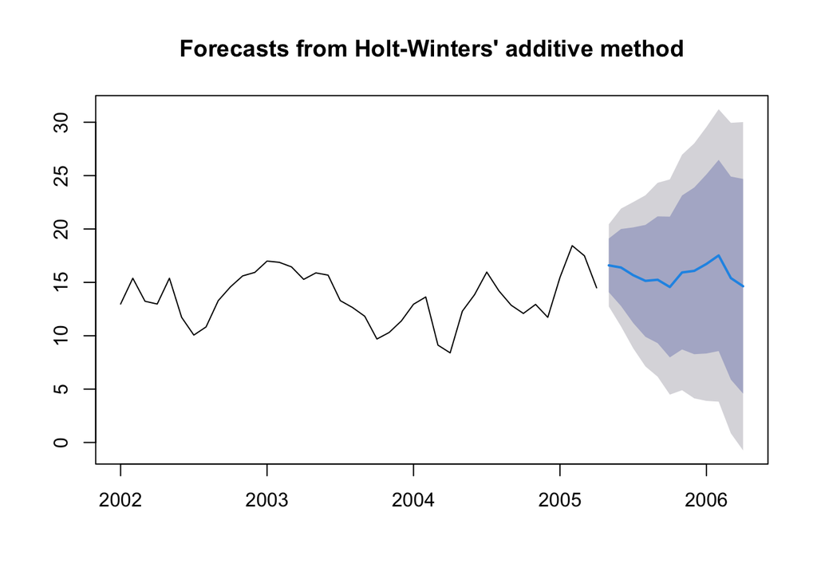

```r
model_forecasting <- forecast(hw_forecast, h=12)
plot(model_forecasting)
```

#### 10. Provide the forecast for the next 12 months (point and range) and explain why you feel confident with these forecasts

```r
print(model_forecasting)
```

```
##          Point Forecast     Lo 80    Hi 80      Lo 95    Hi 95
## May 2005       16.59288 14.075207 19.11055 12.7424310 20.44333
## Jun 2005       16.39019 12.781163 19.99922 10.8706596 21.90972
## Jul 2005       15.67078 11.190837 20.15072  8.8193000 22.52225
## Aug 2005       15.14101  9.898643 20.38337  7.1235028 23.15851
## Sep 2005       15.24483  9.305801 21.18385  6.1618715 24.32778
## Oct 2005       14.56444  7.972919 21.15595  4.4835805 24.64529
## Nov 2005       15.92726  8.714776 23.13975  4.8967153 26.95781
## Dec 2005       16.07874  8.268680 23.88880  4.1342834 28.02320
## Jan 2006       16.72694  8.337148 25.11674  3.8958598 29.55802
## Feb 2006       17.52197  8.566298 26.47765  3.8254509 31.21849
## Mar 2006       15.40104  5.890370 24.91170  0.8557269 29.94635
## Apr 2006       14.63612  4.579076 24.69316 -0.7447997 30.01703
```

#### Conclusion:

The forecast doesn not show an increase or decrease, it expects quotes to stay within a fairly stable range, with some month-to-month fluctuation. This suggests a steady demand for quotes without large seasonal or trend driven changes.